# Explatory Data Analysis

**by Group 3**

## Setup and Installing Libraries

Installing necessary libraries

```python
!pip install matplotlib
!pip install scipy
```

[output not shown]

Java is installed for Pyspark

```python
!sudo yum install -y java-11-amazon-corretto-headless
```

[output not shown]

[output cut: 9 more lines]

[output not shown]

```python
import os
import glob

# Search for the installed Java directory
java_paths = glob.glob('/usr/lib/jvm/java-11*')

if java_paths:
    # Dynamically set the environment variable to the found path
    os.environ["JAVA_HOME"] = java_paths[0]
    print(f"JAVA_HOME successfully set to: {os.environ['JAVA_HOME']}")
else:
    print("Java not found. Did the yum install command work?")
```

```
JAVA_HOME successfully set to: /usr/lib/jvm/java-11-amazon-corretto.x86_64
```

Import necessary libraries

```python
import matplotlib.pyplot as plt
import pandas as pd
import time
import numpy as np
from scipy.stats import chi2_contingency
```

Start a Spark Session

```python
from pyspark.sql import SparkSession
from pyspark.sql.functions import col, count, isnan, when, input_file_name, countDistinct, desc, round, avg, sum
from pyspark.sql.functions import date_format, from_utc_timestamp
import pyspark.sql.functions as F

spark = (
    SparkSession.builder
    .appName("DAT204M-EDA-Sagemaker")
    .master("local[*]")
    .config("spark.jars.packages",
            "org.apache.hadoop:hadoop-aws:3.3.4,com.amazonaws:aws-java-sdk-bundle:1.12.262")
    .config("spark.hadoop.fs.s3a.impl", "org.apache.hadoop.fs.s3a.S3AFileSystem")
    .config("spark.hadoop.fs.s3a.aws.credentials.provider",
            "com.amazonaws.auth.InstanceProfileCredentialsProvider")
    .config("spark.driver.memory", "10g")
    .getOrCreate()
)

INPUT_PATH = "s3a://dat204m-project-g3/cleaned_data_final/"
OUTPUT_PATH = "s3a://dat204m-project-g3/sampled_eda_data/"


print("Spark ready:", spark.version)
```

```
:: loading settings :: url = jar:file:/home/ec2-user/anaconda3/envs/python3/lib/python3.10/site-packages/pyspark/jars/ivy-2.5.0.jar!/org/apache/ivy/core/settings/ivysettings.xml
```

[output not shown]

```
26/07/31 16:06:15 WARN NativeCodeLoader: Unable to load native-hadoop library for your platform... using builtin-java classes where applicable
```

```
Setting default log level to "WARN".
To adjust logging level use sc.setLogLevel(newLevel). For SparkR, use setLogLevel(newLevel).
```

```
Spark ready: 3.3.0
```

## Dataset Overview

This project uses the **MerRec (Mercari Recommendation)** dataset, a large-scale benchmark for consumer-to-consumer (C2C) recommendation systems introduced by Li et al. (2024). The dataset contains anonymized user interaction data from the Mercari e-commerce platform, including user activities, product information, session identifiers, timestamps, product categories, and other item attributes. It was designed to support research on large-scale recommendation systems.

**References**

- **Research Paper:** https://arxiv.org/abs/2402.14230
- **Dataset Repository:** https://huggingface.co/datasets/mercari-us/merrec

### Storage Structure

The dataset was downloaded from the Hugging Face repository and stored in Amazon S3 as Apache Parquet files.

```
s3://dat204m-project-g3/
├── raw/
│   ├── 20230501/
│   ├── 20230601/
│   ├── 20230701/
│   ├── 20230801/
│   ├── 20230901/
│   └── 20231001/
```

**Dataset Characteristics**

- **Source:** Mercari C2C marketplace
- **Storage:** Amazon S3
- **File format:** Apache Parquet
- **Partitioning:** Monthly directories
- **Time span:** Six months of user interaction data collected in 2023
- **Contents:** User interactions, product metadata, session information, timestamps, and product taxonomy.

## Dataset Schema

| Column | Status | Reason |
| --- | --- | --- |
| `user_id` | ✅ Retained | Required for computing unique users and user engagement metrics. |
| `stime` | ✅ Retained | Used for timestamp-based analysis and event ordering. |
| `session_id` | ✅ Retained | Required for calculating unique sessions. |
| `item_id` | ✅ Retained | Retained as the unique listing identifier. |
| `event_id` | ✅ Retained | Used to derive behavioral features (views, likes, cart additions, purchases, etc.). |
| `product_id` | ✅ Retained | Primary entity for product-level clustering. |
| `name` | ✅ Retained | Product title retained for cluster interpretation. |
| `price` | ✅ Retained | Used to compute average product price. |
| `c0_name` | ✅ Retained | Top-level product category used as a categorical feature. |
| `c1_name` | ✅ Retained | Mid-level product category used as a categorical feature. |
| `c2_name` | ✅ Retained | Fine-grained product category used as a categorical feature. |
| `brand_name` | ✅ Retained | Used as a categorical product attribute. |
| `item_condition_name` | ✅ Retained | Used to represent the condition of each product. |
| `year_month` | ✅ Added | Indicates the month from which each record originated after combining multiple monthly datasets. |
| `sequence_id` | ❌ Removed | Sequence-level information was not required for product-level feature engineering. |
| `sequence_length` | ❌ Removed | Sequence statistics were not used in clustering. |
| `c0_id` | ❌ Removed | Replaced by the more interpretable `c0_name`. |
| `c1_id` | ❌ Removed | Replaced by the more interpretable `c1_name`. |
| `c2_id` | ❌ Removed | Replaced by the more interpretable `c2_name`. |
| `brand_id` | ❌ Removed | Replaced by `brand_name`. |
| `item_condition_id` | ❌ Removed | Replaced by `item_condition_name`. |
| `size_name` | ❌ Removed | Product size was not included in the clustering features. |
| `size_id` | ❌ Removed | Product size information was not used. |
| `shipper_name` | ❌ Removed | Shipping payer was not relevant to product clustering. |
| `shipper_id` | ❌ Removed | Corresponding shipping information was excluded. |

## Sampling

```python
# # ==============================================================================
# # DO NOT RUN THIS CELL
# # This script performs the 70GB stratified sampling and writes to S3.
# # It was already executed by Imman.
# # ==============================================================================
# df = spark.read.parquet(INPUT_PATH)

# # Create the stratification key (yyyy-MM)
# df_time = df.withColumn("year_month", date_format("stime", "yyyy-MM"))

# # Dynamically identify all unique months
# # NOTE: This triggers a full read of the 'stime' column across all 180 shards.
# # It will take a few minutes to compute, but it is necessary for stratification.
# print("Scanning dataset to find all unique months (this will take a moment)...")
# distinct_months_rows = df_time.select("year_month").distinct().collect()

# # Clean the list and remove any potential Null timestamps
# distinct_months = [row["year_month"] for row in distinct_months_rows if row["year_month"] is not None]
# print(f"Found {len(distinct_months)} unique months: {distinct_months}")

# # Set up the sampling fractions (e.g., 0.01 for exactly 1% of every month)
# SAMPLE_FRACTION = 0.01
# fractions = {month: SAMPLE_FRACTION for month in distinct_months}

# # Execute the stratified sample
# print(f"Executing stratified sampling at {SAMPLE_FRACTION*100}% per month...")
# df_sampled = df_time.stat.sampleBy("year_month", fractions, seed=42)

# # Save the sampled dataset back to S3
# print(f"Writing sampled data to: {OUTPUT_PATH}")
# # Using coalesce(4) matches your 4 vCPUs. It prevents Spark from writing 180 tiny files,
# # instead outputting 4 clean, medium-sized Parquet files for your team to easily read.
# df_sampled.coalesce(4).write.mode("overwrite").parquet(OUTPUT_PATH)

# print("Stratified sampling complete and saved to S3!")
```

## Overview of the Sample Dataset

As we have saved our sampled data to sample_eda_data in S3, we are going to load it

```python
EDA_DATA_PATH = "s3a://dat204m-project-g3/sampled_eda_data/"
df = spark.read.parquet(EDA_DATA_PATH)
```

```
26/07/31 16:06:22 WARN MetricsConfig: Cannot locate configuration: tried hadoop-metrics2-s3a-file-system.properties,hadoop-metrics2.properties
```

**About the Dataset**

- **Format:** Parquet (columnar, compressed)
- **Storage:** 4 Parquet files
- **File Size:** Approximately **340–370 MB** per file
- **Content:** 1% of data from each month (May to October 2023)
- **Dataset:** Mercari Dataset from HuggingFace (https://huggingface.co/datasets/mercari-us/merrec)

```python
# Enable clean HTML formatting for Spark DataFrames
spark.conf.set("spark.sql.repl.eagerEval.enabled", True)
```

```python
# ==========================================
# PHASE 1: DIRECTORY VALIDATION (The Proof)
# ==========================================
start = time.time()
row_count = df.count()
elapsed = time.time() - start

print("\n--- Validating Directory Contents ---")

# Count total aggregate rows
total_rows = df.count()
total_columns = len(df.columns)

print(f"Total Rows in Dataset: {total_rows:,}")
print(f'Total Columns in Dataset: {total_columns}')
print(f'Counted in {elapsed:.1f} seconds')
```

```
--- Validating Directory Contents ---
Total Rows in Dataset: 11,430,493
Total Columns in Dataset: 14
Counted in 2.5 seconds
```

There are 11,430,493 rows in total and 14 columns across 4 Parquet files

```python
# Extract the unique file names to prove all shards were read
file_distribution = df.withColumn("source_file", input_file_name()) \
    .groupBy("source_file").agg(count("*").alias("row_count"))

total_files_read = file_distribution.count()
print(f"Total Parquet Shards Read: {total_files_read}")

# Display the first 5 shards to verify they match your Athena outputs
print("\nSample of individual files processed:")
file_distribution.show(5, truncate=False)
```

```
Total Parquet Shards Read: 4

Sample of individual files processed:
```

```
[Stage 13:======================================>                  (8 + 4) / 12]
```

```
+-------------------------------------------------------------------------------------------------------------+---------+
|source_file                                                                                                  |row_count|
+-------------------------------------------------------------------------------------------------------------+---------+
|s3a://dat204m-project-g3/sampled_eda_data/part-00000-e4d68cc2-2015-4805-a093-f03af57fd135-c000.snappy.parquet|2864817  |
|s3a://dat204m-project-g3/sampled_eda_data/part-00001-e4d68cc2-2015-4805-a093-f03af57fd135-c000.snappy.parquet|2931512  |
|s3a://dat204m-project-g3/sampled_eda_data/part-00002-e4d68cc2-2015-4805-a093-f03af57fd135-c000.snappy.parquet|2879205  |
|s3a://dat204m-project-g3/sampled_eda_data/part-00003-e4d68cc2-2015-4805-a093-f03af57fd135-c000.snappy.parquet|2754959  |
+-------------------------------------------------------------------------------------------------------------+---------+
```

```python
# ==========================================
# PHASE 2: COMPREHENSIVE EDA
# ==========================================
print("\n--- Basic Schema ---")
df.printSchema()

print("\n--- Checking for Missing Values ---")
# This calculates the exact number of nulls across the features we kept
missing_val_exprs = [
    count(when(isnan(c) | col(c).isNull(), c)).alias(c)
    for c in df.columns
    if df.schema[c].dataType.typeName() not in ['timestamp', 'date']
]
df.select(*missing_val_exprs)
```

```
--- Basic Schema ---
root
 |-- user_id: long (nullable = true)
 |-- stime: timestamp (nullable = true)
 |-- session_id: string (nullable = true)
 |-- item_id: long (nullable = true)
 |-- event_id: string (nullable = true)
 |-- product_id: string (nullable = true)
 |-- name: string (nullable = true)
 |-- price: double (nullable = true)
 |-- c0_name: string (nullable = true)
 |-- c1_name: string (nullable = true)
 |-- c2_name: string (nullable = true)
 |-- brand_name: string (nullable = true)
 |-- item_condition_name: string (nullable = true)
 |-- year_month: string (nullable = true)


--- Checking for Missing Values ---
```

| user_id | session_id | item_id | event_id | product_id | name | price | c0_name | c1_name | c2_name | brand_name | item_condition_name | year_month |
| --- | --- | --- | --- | --- | --- | --- | --- | --- | --- | --- | --- | --- |
| 0 | 0 | 0 | 0 | 0 | 0 | 0 | 0 | 0 | 0 | 0 | 0 | 0 |

From the data above, there are 2 long data, 1 timestamp data, 1 double data, and 10 string values

There are no missing values for all 14 columns

The description of each column in the dataset is shown below:

| Column | Description |
| --- | --- |
| `user_id` | Globally unique user account ID. |
| `session_id` | User-level unique session ID. |
| `stime` | Timestamp in UTC timezone. |
| `year_month` | Derived from `stime` in `YYYY-MM` format, representing the year and month of each event. |
| `event_id` | Action event ID. |
| `item_id` | Globally unique item ID, representing a single listing post. |
| `product_id` | Concatenation of `brand_id` and `c2_id`. |
| `name` | Title text of the item. |
| `price` | Price of the item in USD. |
| `c0_name` | Text label of the item's level-0 category. |
| `c1_name` | Text label of the item's level-1 category. |
| `c2_name` | Text label of the item's level-2 category. |
| `brand_name` | Text label of the item's brand. |
| `item_condition_name` | Text label of the item's condition (e.g., New, Good, Fair). |

```python
print("\n--- Checking for Duplicates ---")

# 1. Group by the specific identifiers and count occurrences
duplicate_groups = df.groupBy("user_id", "stime", "session_id", "item_id").agg(count("*").alias("occurrence_count"))

# 2. Filter to find only the combinations that appear more than once
duplicates = duplicate_groups.filter(col("occurrence_count") > 1)

# 3. Action: Count the total number of duplicate combinations
total_duplicates = duplicates.count()

print(f"Total duplicate combinations found: {total_duplicates:,}")

# 4. Display a sample if duplicates exist
if total_duplicates > 0:
    print("\nSample of duplicated records (sorted by most occurrences):")
    duplicates.orderBy(col("occurrence_count").desc()).show(5, truncate=False)
else:
    print("\nPerfect! No duplicate records found for the given key combination.")
```

```
--- Checking for Duplicates ---
```

```
Total duplicate combinations found: 1,060

Sample of duplicated records (sorted by most occurrences):
```

```
[Stage 30:=======================================>                (12 + 4) / 17]
```

```
+--------+-------------------+----------------------------------------------------------------+---------+----------------+
|user_id |stime              |session_id                                                      |item_id  |occurrence_count|
+--------+-------------------+----------------------------------------------------------------+---------+----------------+
|13932513|2023-05-17 19:25:11|aba3f57e2a01b9612189a46a15f9ec5128759144590b8a43ff48046f7f825111|105981293|2               |
|3813077 |2023-05-02 23:21:38|74aaa59cf09cbbb9951d8839fd6288124be79b969fffa67e0cff347c3a67239a|225905434|2               |
|26105605|2023-05-26 12:10:12|63f737743c5962eff1ada57d660e9064e994ed8df38cfcf0c4401b6976e1da88|105569422|2               |
|55880854|2023-05-20 00:35:25|459a67517703a33f731e709cf13923cb6b4ec607479c101ea1410fa778b95e3d|38662253 |2               |
|29207527|2023-05-15 13:58:15|22a69126eb5eae10ff630c004c9a2d118c75de27ebc9635bdf229f33c54491a8|40914902 |2               |
+--------+-------------------+----------------------------------------------------------------+---------+----------------+
only showing top 5 rows
```

For duplicates, we group it by "user_id", "stime", "session_id", "item_id", as shown above there are 1060 occurences

```python
# Display the first 5 rows
print("\n--- Head of Dataset ---")
df.limit(6)
```

```
--- Head of Dataset ---
```

| user_id | stime | session_id | item_id | event_id | product_id | name | price | c0_name | c1_name | c2_name | brand_name | item_condition_name | year_month |
| --- | --- | --- | --- | --- | --- | --- | --- | --- | --- | --- | --- | --- | --- |
| 54896847 | 2023-05-20 03:09:46 | 9cd412bdcea92541e... | 231043011 | item_view | 22105_1101 | Puff sleeve tie top | 9.0 | Women | Tops & blouses | Blouse | SHEIN | Like new | 2023-05 |
| 54899488 | 2023-05-04 00:46:25 | df7af1950ae474fa6... | 87814591 | item_view | 22635_2990 | 1986 topps baseba... | 80.0 | Toys & Collectibles | Sports Trading Cards | Baseball Trading ... | Topps | Like new | 2023-05 |
| 54902928 | 2023-05-11 05:15:14 | ba782d47de1ba8801... | 31205696 | item_view | 14248_1176 | Vintage Miller Be... | 35.0 | Men | Tops | T-shirts | Miller | Like new | 2023-05 |
| 56163126 | 2023-05-15 00:17:19 | f665ccf7f3caff832... | 224122501 | item_view | 2693_1339 | Bath and Body Wor... | 79.0 | Beauty | Skin care | Body | Bath & Body Works | New | 2023-05 |
| 34163376 | 2023-05-01 17:35:38 | ee8638a1b9f0b1f1a... | 232158130 | item_like | 0_464 | Coach mini phone ... | 80.0 | Women | Women's handbags | Crossbody Bags | None | New | 2023-05 |
| 34164325 | 2023-05-06 04:44:19 | a739ee72e649e0742... | 58444656 | item_view | 12630_2194 | LIKE NEW! RARE ♥️... | 39.0 | Women | Tops & blouses | Tank Tops | lululemon athletica | Like new | 2023-05 |

Convert stime to Asia/Tokyo timezone as currrently it is in UTC timezone

```python
df = df.withColumn(
    "stime_jst",
    from_utc_timestamp("stime", "Asia/Tokyo")
)
```

```python
summary = []

for col in df.columns:
    non_null_count = df.select(F.count(F.col(col))).first()[0]
    distinct_count = df.select(F.countDistinct(F.col(col))).first()[0]

    summary.append((col, non_null_count, distinct_count))

summary_df = spark.createDataFrame(
    summary,
    ["column", "non_null_values", "unique_values"]
)

summary_df.show(truncate=False)
```

```
+-------------------+---------------+-------------+
|column             |non_null_values|unique_values|
+-------------------+---------------+-------------+
|user_id            |11430493       |1990147      |
|stime              |11430493       |7655262      |
|session_id         |11430493       |7358935      |
|item_id            |11430493       |8957840      |
|event_id           |11430493       |6            |
|product_id         |11430493       |449882       |
|name               |11430493       |7400850      |
|price              |11430493       |16932        |
|c0_name            |11430493       |17           |
|c1_name            |11430493       |277          |
|c2_name            |11430493       |2713         |
|brand_name         |11430493       |18405        |
|item_condition_name|11430493       |6            |
|year_month         |11430493       |6            |
|stime_jst          |11430493       |7655262      |
+-------------------+---------------+-------------+
```

The dataset contains **11,430,493 records**, with no missing values across the retained columns. Most identifier and timestamp fields exhibit high cardinality, reflecting the large number of users, sessions, and listings.

**Key highlights:**

- **Users:** 1,990,147 unique users.
- **Sessions:** 7,358,935 unique sessions.
- **Items:** 8,957,840 unique listings mapped to **449,882 unique products**.
- **Categories:** 17 top-level (`c0_name`), 277 mid-level (`c1_name`), and 2,713 fine-grained (`c2_name`) categories.
- **Brands:** 18,405 unique brands.
- **Price:** 16,932 distinct price values.
- **Events:** 6 event types representing user interactions.
- **Item Condition:** 6 condition categories.
- **Time Coverage:** 6 monthly partitions (`year_month`).

## Price Distribution

The `price` variable contains **11,430,493** observations, ranging from **USD 1.00** to **USD 5,000.00**. The median price is **USD 25.00**, with the middle 50% of items priced between **USD 13.54 (Q1)** and **USD 55.00 (Q3)**. The average price (**USD 61.51**) is substantially higher than the median, while the standard deviation (**USD 140.68**) is relatively large. This indicates a **right-skewed distribution**, where most items are listed at lower prices and a smaller number of high-priced items increase the overall mean.

```python
df.agg(
    F.count("price").alias("Count"),
    F.min("price").alias("Minimum"),
    F.expr("percentile_approx(price, 0.25)").alias("Q1"),
    F.expr("percentile_approx(price, 0.5)").alias("Median"),
    F.expr("percentile_approx(price, 0.75)").alias("Q3"),
    F.max("price").alias("Maximum"),
    F.avg("price").alias("Mean"),
    F.stddev("price").alias("Standard Deviation")
).show(truncate=False)
```

```
[Stage 39:>                                                         (0 + 1) / 1]
```

```
+--------+-------+-----+------+----+-------+-----------------+------------------+
|Count   |Minimum|Q1   |Median|Q3  |Maximum|Mean             |Standard Deviation|
+--------+-------+-----+------+----+-------+-----------------+------------------+
|11430493|1.0    |13.54|25.0  |55.0|5000.0 |61.51486253654418|140.67764854937153|
+--------+-------+-----+------+----+-------+-----------------+------------------+
```

The distribution of product prices is **highly right-skewed**, with the majority of items concentrated at the lower end of the price range. Most products are priced below **USD 100**, while only a relatively small number of products have substantially higher prices, extending up to **USD 5,000**. This long right tail is reflected in the descriptive statistics, where the **mean price (USD 61.51)** is considerably higher than the **median price (USD 25.00)**. Additionally, the large **standard deviation (USD 140.68)** indicates substantial variability in product prices, suggesting the presence of high-priced outliers.

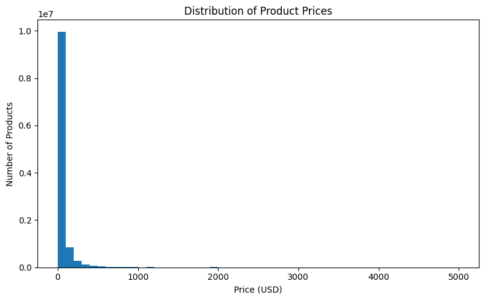

```python
price_df = df.select("price").toPandas()

plt.figure(figsize=(8,5))
plt.hist(price_df["price"], bins=50)
plt.title("Distribution of Product Prices")
plt.xlabel("Price (USD)")
plt.ylabel("Number of Products")
plt.tight_layout()
plt.show()
```

The average product price varies considerably across the 17 top-level categories. **Electronics** has the highest average price (**USD 102.94**), followed by **Tools** (**USD 88.81**), **Other** (**USD 87.07**), and **Sports & Outdoors** (**USD 84.76**). In contrast, **Kids** has the lowest average price (**USD 30.13**), followed by **Pet Supplies** (**USD 34.43**) and **Office** (**USD 34.79**). Overall, technology- and equipment-related categories tend to have higher average prices, whereas children's products, office supplies, and pet products are generally lower priced.

```python
avg_price_category0 = (
    df.groupBy("c0_name")
      .agg(F.avg("price").alias("avg_price"))
      .orderBy(F.desc("avg_price"))
)

avg_price_category0.show()
```

```
[Stage 41:======================================>                  (8 + 4) / 12]
```

```
+--------------------+------------------+
|             c0_name|         avg_price|
+--------------------+------------------+
|         Electronics| 102.9443038964767|
|               Tools| 88.81450926631125|
|               Other| 87.06883790671681|
|   Sports & outdoors| 84.76329964590022|
|                 Men| 75.77431727841737|
|               Books| 70.21197270320184|
|Vintage & collect...| 66.17431124368395|
|               Women| 64.36050920826438|
|    Garden & Outdoor|57.626448149840115|
| Toys & Collectibles| 55.80091990522814|
|            Handmade|55.030767937627175|
|                Home| 46.87858046387187|
|       Arts & Crafts|41.499456278781686|
|              Beauty|41.181788806674575|
|              Office|  34.7880008671048|
|        Pet Supplies|34.434757733934966|
|                Kids|30.127136807096715|
+--------------------+------------------+
```

The average product price also differs substantially across the mid-level (`c1_name`) categories. **Sauna & Hot Tub Equipment** has the highest average price (**USD 280.03**), followed by **Drones** (**USD 251.87**), **Living Room Furniture** (**USD 228.26**), and **Kitchen Furniture** (**USD 222.24**). Other high-priced categories include **Bags and Purses**, **Cameras & Photography**, **Bedroom Furniture**, **Musical Instruments**, and **Computers & Laptops**, all with average prices above **USD 180**. These results indicate that specialized equipment, furniture, electronics, and luxury accessories generally command higher prices than other product categories.

```python
avg_price_category1 = (
    df.groupBy("c1_name")
      .agg(F.avg("price").alias("avg_price"))
      .orderBy(F.desc("avg_price"))
)

avg_price_category1.show()
```

```
[Stage 44:======================================>                  (8 + 4) / 12]
```

```
+--------------------+------------------+
|             c1_name|         avg_price|
+--------------------+------------------+
|Sauna & Hot Tub E...|280.02619718309853|
|              Drones|251.86714412285883|
|Living Room Furni...| 228.2554185152322|
|   Kitchen Furniture|222.23944444444444|
|     Bags and purses|196.88247569298812|
|Cameras & photogr...|193.26247094879324|
|   Bedroom Furniture|193.02094354838707|
| Musical instruments|191.01042195320682|
|     Virtual Reality|181.08447302608073|
| Computers & Laptops|181.00954221912073|
|   Welding Equipment| 179.2587082405345|
|Computer Componen...|178.21515015646165|
|           Strollers|177.71944659407902|
|   Cycling Equipment| 173.1550633855332|
|Outdoor Power Equ...|160.37250085763293|
|           Furniture|160.27326938775514|
|    Women's handbags|151.97299141837473|
| Tablets & E-readers| 140.4877271725961|
|Home Office Furni...|138.42385498174232|
|     Patio Furniture|137.07002930402928|
+--------------------+------------------+
only showing top 20 rows
```

At the fine-grained (`c2_name`) level, average prices exhibit even greater variation. **Pergolas** has the highest average price (**USD 1,490.00**), followed by **Trading Card Games** (**USD 679.67**), **Correction Fluid** (**USD 647.00**), and **Gravel Bike Frames** (**USD 613.03**). Other high-priced categories include **Complete Triathlon Bikes**, **Handbags**, **Welding Machines**, **Living Room Sets**, and **Laptops & Netbooks**, with average prices generally exceeding **USD 390**. These findings indicate that premium outdoor structures, specialized sporting equipment, industrial tools, furniture, and high-value electronics represent the most expensive product categories within the dataset.

```python
avg_price_category2 = (
    df.groupBy("c2_name")
      .agg(F.avg("price").alias("avg_price"))
      .orderBy(F.desc("avg_price"))
)

avg_price_category2.show()
```

```
[Stage 47:==========================================>              (9 + 3) / 12]
```

```
+--------------------+------------------+
|             c2_name|         avg_price|
+--------------------+------------------+
|            Pergolas|            1490.0|
|  Trading Card Games| 679.6666666666666|
|    Correction Fluid|             647.0|
|  Gravel Bike Frames| 613.0333333333333|
|Complete Triathlo...| 532.4117647058823|
|      Marker Refills| 497.2857142857143|
|             Handbag| 468.9415399188091|
|Fusion Splicers &...|           454.875|
|    Welding Machines|454.08315789473676|
|    Living Room Sets|439.65020000000004|
|       Crimping Dies| 433.3333333333333|
|       Hand Crimpers|429.84823529411767|
|Automotive Wheels...| 418.2359064327485|
|            Hot Tubs|            406.75|
|  Laptops & netbooks| 393.6871549893842|
|Patio Furniture Sets| 391.1643367346939|
|      Soldering Guns|           385.892|
|      Tires & wheels| 382.5851704545454|
|DJ, electronic mu...|378.42857142857144|
|Electric Skateboards|365.79953642384106|
+--------------------+------------------+
only showing top 20 rows
```

The table below presents the **top 20 brands with the highest average product prices**. **Devon Leigh** has the highest average price (**USD 2,000.00**), followed by **Rickenbacker** (**USD 1,900.00**), **Bemer** (**USD 1,650.00**), **Kelly Faetanini** (**USD 1,628.00**), and **KW Suspension** (**USD 1,600.00**). Other premium brands, including **Rolex**, **Jacob & Co.**, **Vacheron Constantin**, and **Neil Lane**, also exhibit average prices exceeding **USD 1,000**. These results indicate that luxury brands and specialized manufacturers are associated with substantially higher-priced products within the dataset.

```python
avg_price_brand_name = (
    df.groupBy("brand_name")
      .agg(F.avg("price").alias("avg_price"))
      .orderBy(F.desc("avg_price"))
)

avg_price_brand_name.show()
```

```
[Stage 50:==============================================>         (10 + 2) / 12]
```

```
+-------------------+------------------+
|         brand_name|         avg_price|
+-------------------+------------------+
|        Devon Leigh|            2000.0|
|       Rickenbacker|            1900.0|
|              Bemer|            1650.0|
|    Kelly Faetanini|            1628.0|
|      KW Suspension|            1600.0|
|            Lakland|            1550.0|
|         Coolstream|            1425.0|
|       Rue De Seine|1255.5555555555557|
|              Rolex|1210.9507475317348|
|    Brooklyn Motors|            1150.0|
|        Jacob & Co.|           1148.32|
|          Neil Lane| 1146.568054054054|
|Sequential Circuits| 1129.142857142857|
|             Hartke|            1100.0|
|             Gorski|            1100.0|
|             Imacon|            1100.0|
|      Martina Liana|1092.7890909090909|
|Vacheron Constantin| 1062.142857142857|
|           Permobil|            1059.8|
|      Paloma Blanca|           1052.25|
+-------------------+------------------+
only showing top 20 rows
```

The average product price varies modestly across item conditions. Products with an unspecified condition (**None**) have the highest average price (**USD 71.12**), followed by **Like New** (**USD 66.21**). Items listed as **New**, **Good**, **Poor**, and **Fair** have average prices ranging from **USD 55.74** to **USD 60.27**. Overall, the relatively small differences suggest that item condition has a less pronounced effect on average price compared with product category or brand.

```python
avg_price_item_condition = (
    df.groupBy("item_condition_name")
      .agg(F.avg("price").alias("avg_price"))
      .orderBy(F.desc("avg_price"))
)

avg_price_item_condition.show()
```

```
[Stage 53:======================================>                  (8 + 4) / 12]
```

```
+-------------------+------------------+
|item_condition_name|         avg_price|
+-------------------+------------------+
|               None| 71.11878855444074|
|           Like new|  66.2061316194585|
|                New| 60.26526823580089|
|               Good|59.953399417708944|
|               Poor| 58.91897091318143|
|               Fair| 55.73581727737282|
+-------------------+------------------+
```

The average product price remained relatively stable across the six-month period, fluctuating within a narrow range of approximately **USD 60–63**. The highest average price was observed in **May 2023** (approximately **USD 62.7**), followed by a decline in **June**, a slight recovery in **July**, and a gradual downward trend from **August** to **October**, where the lowest average price (approximately **USD 60.1**) was recorded. Overall, the modest month-to-month variations suggest that product pricing remained relatively consistent throughout the observation period, with no significant seasonal fluctuations.

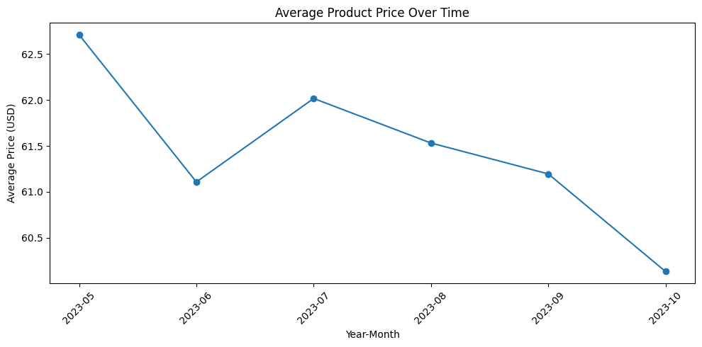

```python
avg_price_month = (
    df.withColumn("year_month", F.date_format(F.col("stime_jst"), "yyyy-MM"))
      .groupBy("year_month")
      .agg(F.avg("price").alias("avg_price"))
      .orderBy("year_month")
)

price_month_df = avg_price_month.toPandas()

plt.figure(figsize=(10,5))
plt.plot(price_month_df["year_month"], price_month_df["avg_price"], marker="o")
plt.title("Average Product Price Over Time")
plt.xlabel("Year-Month")
plt.ylabel("Average Price (USD)")
plt.xticks(rotation=45)
plt.tight_layout()
plt.show()
```

## Category and Brand distributions

The dataset contains a hierarchical product taxonomy consisting of **17 top-level categories (`c0_name`)**, **277 mid-level categories (`c1_name`)**, and **2,713 fine-grained categories (`c2_name`)**. In addition, there are **18,405 unique brands**, indicating a highly diverse marketplace with products spanning a wide range of categories and manufacturers.

```python
df.select(
    countDistinct("c0_name").alias("Unique C0 Categories"),
    countDistinct("c1_name").alias("Unique C1 Categories"),
    countDistinct("c2_name").alias("Unique C2 Categories"),
    countDistinct("brand_name").alias("Unique Brand Names")
).show()
```

```
[Stage 64:==========================================>              (9 + 3) / 12]
```

```
+--------------------+--------------------+--------------------+------------------+
|Unique C0 Categories|Unique C1 Categories|Unique C2 Categories|Unique Brand Names|
+--------------------+--------------------+--------------------+------------------+
|                  17|                 277|                2713|             18405|
+--------------------+--------------------+--------------------+------------------+
```

The distribution of products across the top-level (`c0_name`) categories is highly imbalanced. **Women** is the largest category by a substantial margin, containing approximately **3.8 million** products, followed by **Toys & Collectibles** with around **2.2 million** products. Other major categories include **Men**, **Kids**, **Home**, and **Electronics**, each containing between **0.7 and 1.1 million** products. In contrast, categories such as **Books** and **Other** contribute relatively few products. Overall, the results indicate that fashion-related categories, particularly **Women**, dominate the marketplace, reflecting a skewed distribution of products across top-level categories.

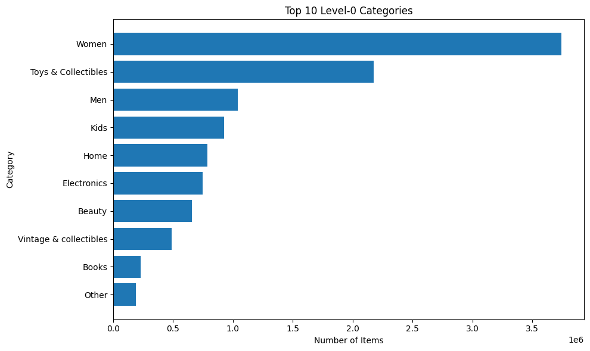

```python
top_c0 = (
    df.groupBy("c0_name")
      .count()
      .orderBy(F.desc("count"))
      .limit(10)
)

top_c0_df = top_c0.toPandas()

plt.figure(figsize=(10, 6))
plt.barh(top_c0_df["c0_name"], top_c0_df["count"])
plt.gca().invert_yaxis()
plt.title("Top 10 Level-0 Categories")
plt.xlabel("Number of Items")
plt.ylabel("Category")
plt.tight_layout()
plt.show()
```

Among the mid-level (`c1_name`) categories, **Shoes** contains the largest number of products by a considerable margin. It is followed by **Collectibles & Hobbies**, **Women's Handbags**, **Athletic Apparel**, and **Action Figures & Accessories**, all of which represent major product segments within the marketplace. The dominance of footwear, fashion accessories, and collectibles indicates that consumer goods and lifestyle products account for a substantial proportion of the listings. Overall, the distribution is skewed, with a relatively small number of mid-level categories contributing a large share of the products.

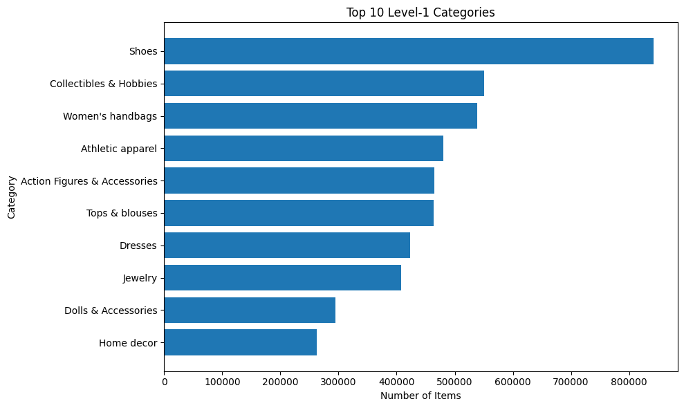

```python
top_c1 = (
    df.groupBy("c1_name")
      .count()
      .orderBy(F.desc("count"))
      .limit(10)
)

top_c1_df = top_c1.toPandas()

plt.figure(figsize=(10, 6))
plt.barh(top_c1_df["c1_name"], top_c1_df["count"])
plt.gca().invert_yaxis()
plt.title("Top 10 Level-1 Categories")
plt.xlabel("Number of Items")
plt.ylabel("Category")
plt.tight_layout()
plt.show()
```

At the fine-grained (`c2_name`) level, the product distribution remains highly concentrated among a small number of categories. **Other** is the largest category, followed by **Action Figures**, **T-shirts**, and **Athletic** products. Additional frequently occurring categories include **Stuffed Animals**, **Women**, **Girls 2T–5T**, **Fashion Dolls**, **Shoulder Bags**, and **Girls (4+)**. The prominence of apparel, toys, and fashion-related categories indicates that these product types account for a significant proportion of listings. Overall, the distribution is highly imbalanced, with a few fine-grained categories containing a large share of products while the remaining categories have relatively fewer listings.

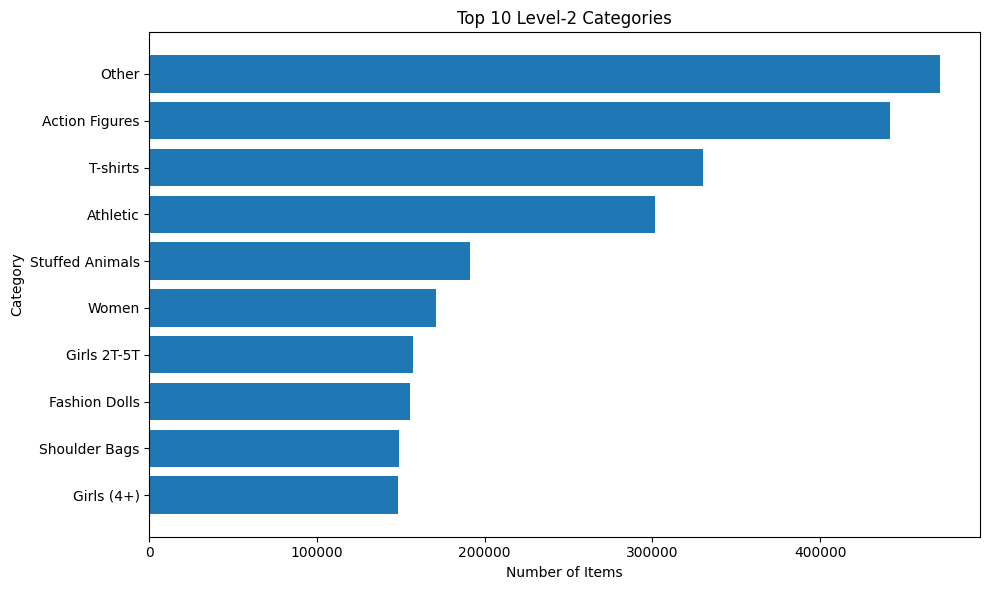

```python
top_c2 = (
    df.groupBy("c2_name")
      .count()
      .orderBy(F.desc("count"))
      .limit(10)
)

top_c2_df = top_c2.toPandas()

plt.figure(figsize=(10, 6))
plt.barh(top_c2_df["c2_name"], top_c2_df["count"])
plt.gca().invert_yaxis()
plt.title("Top 10 Level-2 Categories")
plt.xlabel("Number of Items")
plt.ylabel("Category")
plt.tight_layout()
plt.show()
```

The most common category hierarchies reveal that products are concentrated in a few specific segments of the marketplace. The largest hierarchy is **Toys & Collectibles → Action Figures & Accessories → Action Figures**, with **438,909** listings. Other frequently occurring hierarchies include **Toys & Collectibles → Stuffed Animals & Plush → Stuffed Animals** (**191,471**), **Men → Shoes → Athletic** (**189,155**), and **Men → Tops → T-shirts** (**177,320**). Fashion and beauty products are also well represented, with **Women's T-shirts**, **Women's Shoulder Bags**, **Crossbody Bags**, and **Beauty → Fragrance → Women** among the most common combinations. Overall, the results indicate that **toys, apparel, handbags, and beauty products** constitute the largest product segments within the dataset.

```python
top_category_combinations = (
    df.groupBy("c0_name", "c1_name", "c2_name")
      .count()
      .orderBy(F.desc("count"))
)

top_category_combinations.show(10, truncate=False)
```

```
[Stage 79:======================================>                  (8 + 4) / 12]
```

```
+-------------------+----------------------------+---------------+------+
|c0_name            |c1_name                     |c2_name        |count |
+-------------------+----------------------------+---------------+------+
|Toys & Collectibles|Action Figures & Accessories|Action Figures |438909|
|Toys & Collectibles|Stuffed Animals & Plush     |Stuffed Animals|191471|
|Men                |Shoes                       |Athletic       |189155|
|Men                |Tops                        |T-shirts       |177320|
|Beauty             |Fragrance                   |Women          |169515|
|Toys & Collectibles|Dolls & Accessories         |Fashion Dolls  |155656|
|Women              |Tops & blouses              |T-shirts       |152624|
|Women              |Women's handbags            |Shoulder Bags  |149025|
|Toys & Collectibles|Trading Cards               |Single Cards   |139934|
|Women              |Women's handbags            |Crossbody Bags |139093|
+-------------------+----------------------------+---------------+------+
only showing top 10 rows
```

The distribution of brands is highly skewed, with **None** representing the largest group by a substantial margin, indicating that many product listings do not specify a brand. Among the identified brands, **Nike** is the most frequently occurring, followed by **Disney**, **Handmade**, **lululemon athletica**, **Funko**, **Nintendo**, **Pokemon**, **BTS**, and **Coach**. The prominence of these brands reflects strong representation from the fashion, entertainment, collectibles, and gaming sectors. Overall, while the marketplace contains **18,405 unique brands**, only a small number of brands account for a large proportion of the branded product listings.

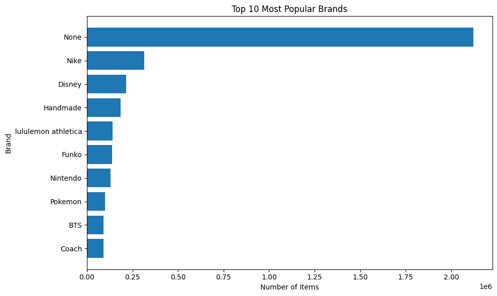

```python
top_brands = (
    df.groupBy("brand_name")
      .count()
      .orderBy(F.desc("count"))
      .limit(10)
)

top_brands_df = top_brands.toPandas()

plt.figure(figsize=(10,6))
plt.barh(top_brands_df["brand_name"], top_brands_df["count"])
plt.title("Top 10 Most Popular Brands")
plt.xlabel("Number of Items")
plt.ylabel("Brand")
plt.gca().invert_yaxis()
plt.tight_layout()
plt.show()
```

The top 10 brands account for a notable share of the product listings. Products with an unspecified brand (**None**) constitute the largest group, representing **2,120,636 listings (18.55%)**, indicating that nearly one-fifth of the dataset does not contain brand information. Among the identified brands, **Nike** is the most common (**315,580 listings; 2.76%**), followed by **Disney** (**1.88%**), **Handmade** (**1.63%**), **lululemon athletica** (**1.24%**), and **Funko** (**1.21%**). Other frequently occurring brands include **Nintendo**, **Pokemon**, **BTS**, and **Coach**, each contributing less than **1.2%** of the total listings. Overall, despite the presence of **18,405 unique brands**, the distribution is highly skewed, with a relatively small number of brands accounting for a significant proportion of branded products.

```python
total_products = df.count()

brand_percentage = (
    df.groupBy("brand_name")
      .agg(count("*").alias("product_count"))
      .withColumn(
          "percentage",
          round((col("product_count") / total_products) * 100, 2)
      )
      .orderBy(desc("product_count"))
)

brand_percentage.show(10, truncate=False)
```

```
[Stage 88:==========================================>              (9 + 3) / 12]
```

```
+-------------------+-------------+----------+
|brand_name         |product_count|percentage|
+-------------------+-------------+----------+
|None               |2120636      |18.55     |
|Nike               |315580       |2.76      |
|Disney             |214425       |1.88      |
|Handmade           |186020       |1.63      |
|lululemon athletica|141833       |1.24      |
|Funko              |138388       |1.21      |
|Nintendo           |131112       |1.15      |
|Pokemon            |98867        |0.86      |
|BTS                |92593        |0.81      |
|Coach              |91917        |0.8       |
+-------------------+-------------+----------+
only showing top 10 rows
```

## Item Condition

The distribution of item conditions is heavily concentrated in the **Good**, **New**, and **Like New** categories. **Good** is the most common condition, closely followed by **New**, with both accounting for the majority of product listings. **Like New** is the third most frequent condition but occurs substantially less often than the top two categories. In contrast, relatively few products are listed as **Fair** or **Poor**, while listings with an unspecified condition (**None**) are negligible. Overall, the marketplace is dominated by products in good or new condition, suggesting that most listings are either well-maintained or newly offered.

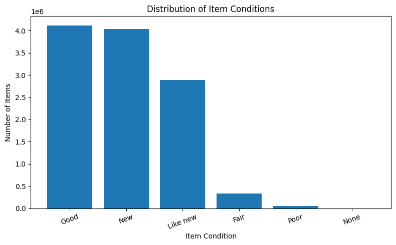

```python
condition_dist = (
    df.groupBy("item_condition_name")
      .count()
      .orderBy(F.desc("count"))
)

item_condition_df = condition_dist.toPandas()

plt.figure(figsize=(8,5))
plt.bar(item_condition_df["item_condition_name"], item_condition_df["count"])
plt.title("Distribution of Item Conditions")
plt.xlabel("Item Condition")
plt.ylabel("Number of Items")
plt.xticks(rotation=20)
plt.tight_layout()
plt.show()
```

## User & Session Analysis

The dataset contains **1,990,147 unique users** who generated **7,358,935 unique sessions**, indicating that many users interacted with the platform multiple times during the observation period. The substantially higher number of sessions than users suggests repeated engagement, with users returning to browse, interact with, or purchase products across multiple shopping sessions.

```python
unique_users = df.select("user_id").distinct().count()
unique_sessions = df.select("session_id").distinct().count()

print('Number of Unique Users:', unique_users)
print('Number of Unique Sessions:', unique_sessions)
```

```
[Stage 107:============================================>           (8 + 2) / 10]
```

```
Number of Unique Users: 1990147
Number of Unique Sessions: 7358935
```

The table below lists the **top 10 most active users** based on the total number of recorded events. The most active user generated **1,375 events**, followed by users with **1,240**, **1,151**, and **1,129** events. Overall, these users exhibit substantially higher activity levels than the average user, indicating that a small subset of users contributes a disproportionately large number of interactions. Such highly active users may represent frequent buyers, sellers, or highly engaged users on the platform.

```python
user_activity = (
    df.groupBy("user_id")
      .agg(count("*").alias("event_count"))
      .orderBy("event_count", ascending=False)
)

user_activity.show(10)
```

```
[Stage 113:>                                                        (0 + 4) / 4]
```

```
+--------+-----------+
| user_id|event_count|
+--------+-----------+
|50727525|       1375|
| 8300879|       1240|
|32736302|       1151|
|18148080|       1129|
|53991826|       1107|
|27303979|       1082|
|50009461|        965|
|13649653|        962|
|16891288|        947|
|26243510|        920|
+--------+-----------+
only showing top 10 rows
```

On average, each user generated approximately **5.74 events** during the observation period. This indicates that most users interacted with the platform multiple times, such as viewing, liking, adding items to the cart, or making purchases. Compared with the most active users, who generated over **900 events**, the average event count is considerably lower, suggesting a **highly skewed distribution of user activity**, where a relatively small proportion of users contribute a disproportionately large number of interactions.

```python
user_activity.select(avg("event_count").alias("Average Event Count")).show()
```

```
[Stage 116:>                                                        (0 + 4) / 4]
```

```
+-------------------+
|Average Event Count|
+-------------------+
|  5.743542059958385|
+-------------------+
```

The table below presents the **top 10 most active sessions** based on the number of recorded events. The most active session contains **29 events**, followed by sessions with **25**, **24**, and **23** events. The remaining top sessions each contain **21–22 events**. Compared with the average user activity, these sessions represent periods of relatively high engagement, where users performed multiple interactions—such as viewing items, liking products, adding items to the cart, or initiating purchases—within a single browsing session.

```python
session_activity = (
    df.groupBy("session_id")
      .agg(count("*").alias("event_count"))
      .orderBy("event_count", ascending=False)
)

session_activity.show(10)
```

```
[Stage 122:============================================>           (8 + 2) / 10]
```

```
+--------------------+-----------+
|          session_id|event_count|
+--------------------+-----------+
|f8d772bebc5329728...|         29|
|885bbc5bd9d77eba9...|         25|
|65218d7bfda28aadd...|         24|
|1dd261549e944ccd6...|         23|
|18adfba35eea05da6...|         22|
|b80775716587e6a76...|         21|
|d1eef3c7f1e3b6ff6...|         21|
|12bcf886ea2f0f135...|         21|
|f14f82995f9ba789a...|         21|
|48a6734b65a60de36...|         21|
+--------------------+-----------+
only showing top 10 rows
```

Each session contains an average of **1.55 events**, indicating that most browsing sessions consist of only one or two user interactions. Compared with the most active sessions, which contain up to **29 events**, the average is considerably lower, suggesting that while the majority of sessions are relatively short, a small number of sessions involve substantially higher levels of user engagement. This pattern is consistent with a right-skewed distribution of session activity, where most sessions are brief and only a few include many interactions.

```python
session_activity.select(avg("event_count").alias("Average Event Count")).show()
```

```
[Stage 125:============================================>           (8 + 2) / 10]
```

```
+-------------------+
|Average Event Count|
+-------------------+
| 1.5532808755614773|
+-------------------+
```

The table below lists the **top 10 users with the highest number of sessions**. The most active user recorded **756 sessions**, followed by users with **712**, **686**, and **677** sessions. The remaining users each generated more than **560 sessions** during the observation period. These results indicate that a small subset of users returned to the platform hundreds of times, reflecting a high level of sustained engagement compared with the typical user.

```python
sessions_per_user = (
    df.groupBy("user_id")
      .agg(countDistinct("session_id").alias("session_count"))
      .orderBy(desc("session_count"))
)

sessions_per_user.show(10)
```

```
[Stage 134:>                                                        (0 + 4) / 4]
```

```
+--------+-------------+
| user_id|session_count|
+--------+-------------+
| 8300879|          756|
| 6937872|          712|
|50727525|          686|
|27303979|          677|
| 9497805|          619|
|18148080|          616|
|13383611|          606|
|32736302|          581|
|53991826|          562|
|15114184|          560|
+--------+-------------+
only showing top 10 rows
```

## Temporal Analysis

User interactions are dominated by **item views**, which account for **9,513,720** events, indicating that browsing is the primary activity on the platform. This is followed by **item likes** with **1,638,210** events, suggesting that many users express interest in products without immediately purchasing them. Purchase-related interactions occur much less frequently, with **176,941** add-to-cart events, **66,888** offers made, **24,516** purchase initiations (`buy_start`), and **10,218** completed purchases (`buy_comp`). Overall, the event distribution illustrates a typical e-commerce conversion funnel, where user interactions decrease substantially from product viewing to completed purchases.

```python
event_distribution = (
    df.groupBy("event_id")
      .count()
      .orderBy(desc("count"))
)

event_distribution.show()
```

```
[Stage 135:=====================================>                  (8 + 4) / 12]
```

```
+--------------------+-------+
|            event_id|  count|
+--------------------+-------+
|           item_view|9513720|
|           item_like|1638210|
|item_add_to_cart_tap| 176941|
|          offer_make|  66888|
|           buy_start|  24516|
|            buy_comp|  10218|
+--------------------+-------+
```

User activity increased steadily from **May to August**, reaching its highest level in **August**, before experiencing a slight decline in **September**, suggesting overall growth in user engagement with minor seasonal or marketplace fluctuations.

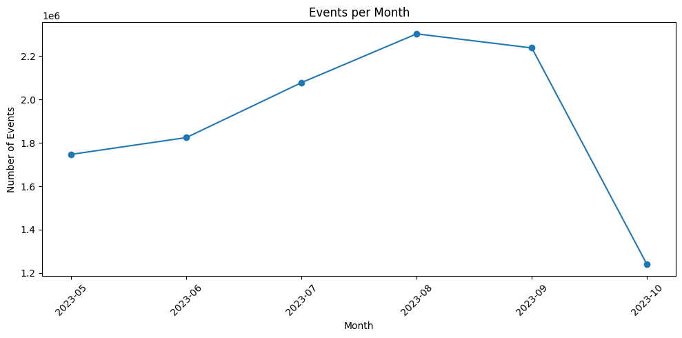

```python
events_month = (
    df.withColumn("year_month", F.date_format(F.col("stime"), "yyyy-MM"))
      .groupBy("year_month")
      .count()
      .orderBy("year_month")
)

events_month_df = events_month.toPandas()

plt.figure(figsize=(10, 5))
plt.plot(events_month_df["year_month"], events_month_df["count"], marker="o")

plt.title("Events per Month")
plt.xlabel("Month")
plt.ylabel("Number of Events")
plt.xticks(rotation=45)
plt.tight_layout()
plt.show()
```

Event activity remained relatively stable throughout the week, with **Monday** recording the highest number of events and **Saturday** the lowest. The small differences between days indicate a consistent level of user activity, with slightly higher engagement observed at the beginning and end of the week.

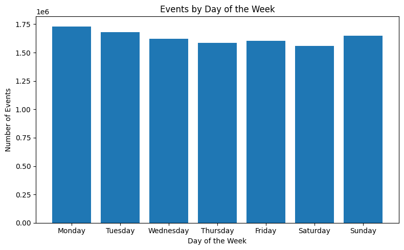

```python
events_weekday = (
    df.withColumn("day_of_week", F.date_format("stime_jst", "EEEE"))
      .groupBy("day_of_week")
      .count()
)

weekday_order = ["Monday", "Tuesday", "Wednesday",
                 "Thursday", "Friday", "Saturday", "Sunday"]

events_weekday_df = events_weekday.toPandas()
events_weekday_df["day_of_week"] = pd.Categorical(
    events_weekday_df["day_of_week"],
    categories=weekday_order,
    ordered=True
)
events_weekday_df = events_weekday_df.sort_values("day_of_week")


plt.figure(figsize=(8,5))
plt.bar(events_weekday_df["day_of_week"], events_weekday_df["count"])
plt.title("Events by Day of the Week")
plt.xlabel("Day of the Week")
plt.ylabel("Number of Events")
plt.tight_layout()
plt.show()
```

Event activity increased steadily from **midnight (12:00 AM JST)** through the morning, reaching its highest level at **11:00 AM JST**, before declining sharply during the afternoon and reaching its lowest point at **6:00 PM JST**. Activity then gradually recovered throughout the evening, indicating that user engagement is strongest during the late morning and weakest during the early evening.

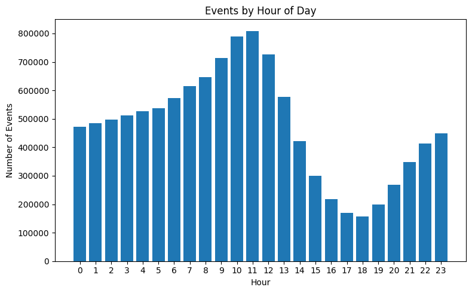

```python
events_hour = (
    df.groupBy(F.hour("stime_jst").alias("hour"))
      .count()
      .orderBy("hour")
)

events_hour_df = events_hour.toPandas()

plt.figure(figsize=(8,5))
plt.bar(events_hour_df["hour"], events_hour_df["count"], width=0.8)
plt.title("Events by Hour of Day")
plt.xlabel("Hour")
plt.ylabel("Number of Events")
plt.xticks(range(24))
plt.tight_layout()
plt.show()
```

## Product Analysis

The dataset contains **449,882 unique products**, represented by distinct `product_id` values. Since a single product may be associated with multiple user interactions and listings over time, this reflects the breadth of products available on the platform and serves as the foundation for the product-level feature engineering and clustering performed in this study.

```python
df.select(
    countDistinct("product_id").alias("unique_products")
).show()
```

```
[Stage 177:==================================================>    (11 + 1) / 12]
```

```
+---------------+
|unique_products|
+---------------+
|         449882|
+---------------+
```

The table below presents the **top 10 most viewed products** based on the number of `item_view` events. The most viewed product, **Nike Air Jordan 1 Mid Blackout Triple Black Shoes**, received **64,092 views**, followed by **South Park Professor Chaos Funko Pop** (**46,929 views**) and **Rawcliffe Pewter Story Teller** (**43,373 views**). Other highly viewed products include **The Legend of Zelda: Skyward Sword Bundle**, **Rustic Wood Cross**, **Air Jordan 3 Retro**, and **Nike Air Max 270 Shoes**. The list is dominated by products from the **athletic footwear, collectibles, gaming, and home décor** categories, suggesting that these product types attracted the greatest user attention during the observation period.

```python
df.filter(F.col("event_id") == "item_view") \
  .groupBy("product_id") \
  .agg(
      F.first("name").alias("product_name"),
      F.first("brand_name").alias("brand"),
      F.first("c2_name").alias("c2 category"),
      F.count("*").alias("view_count")
  ) \
  .orderBy(F.desc("view_count")) \
  .show(10, truncate=False)
```

```
[Stage 204:>                                                        (0 + 4) / 4]
```

```
+----------+-------------------------------------------------------------------------+----------+------------------+----------+
|product_id|product_name                                                             |brand     |c2 category       |view_count|
+----------+-------------------------------------------------------------------------+----------+------------------+----------+
|15987_1224|Nike Air Jordan 1 Mid Blackout Triple Black 554724-030 Shoes Men’s Size 7|Nike      |Athletic          |64092     |
|7969_2428 |South Park Professor Chaos Funko Pop                                     |Funko     |Bobbleheads       |46929     |
|0_561     |Rawcliffe pewter story teller                                            |None      |Action Figures    |43373     |
|15928_1315|The Legend of Zelda Skyward Sword Bundle                                 |Nintendo  |Games             |42931     |
|0_904     |Rustic wood cross                                                        |None      |Home decor accents|40745     |
|9814_561  |GI Joe custom classified Franklin Talltree Codename Airborne             |Hasbro    |Action Figures    |34576     |
|436_1224  |Air Jordan 3 Retro                                                       |Air Jordan|Athletic          |32731     |
|3838_585  |skz THE SOUND album pc                                                   |BTS       |Paper Collectibles|31742     |
|8886_1176 |Fdny Memorial Shirt (Bronx) E93 L48 B3 Hunts Point (Size XL)             |Gildan    |T-shirts          |31519     |
|15987_1167|Nike Air Max 270 Shoes                                                   |Nike      |Athletic          |30331     |
+----------+-------------------------------------------------------------------------+----------+------------------+----------+
only showing top 10 rows
```

The table below presents the **top 10 most purchased products** based on completed purchase (`buy_comp`) events. **Squishmallows Ludwig the Frog 8”** recorded the highest number of completed purchases (**127**), followed by **Kirby 64: The Crystal Shards** (**117**) and **Dr. Harleen Suicide Squad Funko Pop** (**111**). Other frequently purchased products include **Harry Potter: The Knight Bus LEGO Set**, **BTS Photocard**, **Nike Blazer 77 Mid EMB**, **Pokémon Light Togetic Neo Destiny**, and **Devil May Cry HD Collection**. The top purchased products span a variety of categories, including **collectibles, video games, toys, athletic footwear, trading cards, and apparel**, indicating that consumer demand is distributed across multiple product segments rather than concentrated in a single category.

```python
df.filter(F.col("event_id") == "buy_comp") \
  .groupBy("product_id") \
  .agg(
      F.first("name").alias("product_name"),
      F.first("brand_name").alias("brand"),
      F.first("c2_name").alias("c2 category"),
      F.count("*").alias("purchase_count")
  ) \
  .orderBy(F.desc("purchase_count")) \
  .show(10, truncate=False)
```

```
[Stage 205:=============================================>         (10 + 2) / 12]
```

```
+----------+------------------------------------------------------------------------+-------------+------------------+--------------+
|product_id|product_name                                                            |brand        |c2 category       |purchase_count|
+----------+------------------------------------------------------------------------+-------------+------------------+--------------+
|20165_645 |Squismallows ludwing the Frog 8”                                        |Squishmallows|Stuffed Animals   |127           |
|15928_1315|Kirby 64 The Crystal Shards                                             |Nintendo     |Games             |117           |
|7969_2428 |Dr Harleen Suicide Squad Funko Pop Item #135                            |Funko        |Bobbleheads       |111           |
|12864_2430|Harry Potter The Knight Bus LEGO 75957                                  |LEGO         |LEGO Toys         |89            |
|3838_585  |BTS photocard ON HOLD DONT BUY                                          |BTS          |Paper Collectibles|69            |
|15987_1224|Nike Blazer 77 Mid EMB Phantom/Hot Curry-Pearl White Size 13            |Nike         |Athletic          |64            |
|17470_3525|Pokemon Light Togetic Neo Destiny                                       |Pokemon      |Single Cards      |63            |
|20652_1315|Devil May Cry HD Collection For Playstation 4                           |Sony         |Games             |62            |
|8886_1176 |Atlanta Braves Signatures T-shirt                                       |Gildan       |T-shirts          |49            |
|0_561     |ACTION FORCE GUN FOR 6 INCH SCALE 1/12 MILITARY ACTION FIGURE WEAPON LOT|None         |Action Figures    |47            |
+----------+------------------------------------------------------------------------+-------------+------------------+--------------+
only showing top 10 rows
```

```python
df.groupBy("product_id") \
  .agg(
      F.first("name").alias("product_name"),
      F.first("brand_name").alias("brand"),
      F.first("c2_name").alias("c2 category"),
      F.avg("price").alias("avg_price")
  ) \
  .orderBy(F.desc("avg_price")) \
  .show(10, truncate=False)
```

```
[Stage 210:>                                                        (0 + 4) / 4]
```

```
+----------+-----------------------------------------------------+--------------+----------------------+-----------------+
|product_id|product_name                                         |brand         |c2 category           |avg_price        |
+----------+-----------------------------------------------------+--------------+----------------------+-----------------+
|19587_1159|Roberto Coin double symphony pois moi Diamond bangle |Roberto Coin  |Bracelets             |4800.0           |
|4769_459  |Chanel handbag                                       |Chanel        |Messenger Bags        |3098.125         |
|12906_765 |Louis Vuitton Speedy Bandouliere Bag                 |Louis Vuitton |Work & safety         |2769.0           |
|18652_1154|rolex watch BOX 5X4 INCH GREEN                       |Rolex         |Watches               |2615.617435897436|
|13718_2868|Resident Evil Watch MSTR Capcom #148-500             |Meister       |Video Game Merchandise|2000.0           |
|1855_1157 |TRIPLE AMETHYST RING IN 14KT YELLOW GOLD             |A by Amanda   |Rings                 |2000.0           |
|15188_1312|The last of us Mondo Limited Posters Collection      |Mondo         |Other                 |2000.0           |
|15303_1366|Vintage collectible record player unit "Marantz 6300"|Marantz       |Lighting              |2000.0           |
|12799_1413|silverware lot                                       |Lot           |Housewares            |2000.0           |
|15712_1442|Nancy Gonzalez pink Croc crossbody Clutch NEW        |Nancy Gonzalez|Clutch                |2000.0           |
+----------+-----------------------------------------------------+--------------+----------------------+-----------------+
only showing top 10 rows
```

The table below presents the **top 10 products with the highest average prices**, together with their minimum and maximum listing prices. **Roberto Coin Double Symphony Pois Moi Diamond Bangle** has the highest average price (**USD 4,800.00**) and was consistently listed at that price. This is followed by a **Chanel Handbag** with an average price of **USD 3,098.13**, although its listings ranged widely from **USD 435.00** to **USD 4,700.00**, indicating substantial price variation across listings. Similarly, the **Rolex Watch** recorded an average price of **USD 2,615.62**, with prices ranging from **USD 30.00** to **USD 5,000.00**, suggesting differences in product condition, completeness, or listing characteristics. Most of the remaining products maintained a fixed average, minimum, and maximum price of **USD 2,000.00**, indicating consistent pricing across their listings. Overall, luxury jewelry, handbags, watches, and premium specialty products dominate the highest-priced items in the marketplace.

```python
df.groupBy("product_id") \
  .agg(
      F.first("name").alias("product_name"),
      F.first("brand_name").alias("brand"),
      F.first("c2_name").alias("c2 category"),
      F.avg("price").alias("avg_price"),
      F.min("price").alias("min_price"),
      F.max("price").alias("max_price")
  ) \
  .orderBy(F.desc("avg_price")) \
  .show(10, truncate=False)
```

```
[Stage 213:>                                                        (0 + 4) / 5]
```

```
+----------+-------------------------------------------------------------------------------+--------------+-----------------+-----------------+---------+---------+
|product_id|product_name                                                                   |brand         |c2 category      |avg_price        |min_price|max_price|
+----------+-------------------------------------------------------------------------------+--------------+-----------------+-----------------+---------+---------+
|19587_1159|Roberto Coin double symphony pois moi Diamond bangle                           |Roberto Coin  |Bracelets        |4800.0           |4800.0   |4800.0   |
|4769_459  |Chanel handbag                                                                 |Chanel        |Messenger Bags   |3098.125         |435.0    |4700.0   |
|12906_765 |Louis Vuitton Speedy Bandouliere Bag                                           |Louis Vuitton |Work & safety    |2769.0           |2769.0   |2769.0   |
|18652_1154|rolex watch BOX 5X4 INCH GREEN                                                 |Rolex         |Watches          |2615.617435897436|30.0     |5000.0   |
|12246_474 |KEITH HARING EARTHMAM 518/1000 PAINTING                                        |Keith Haring  |Artwork          |2000.0           |2000.0   |2000.0   |
|18919_1070|1000s of Car Parts Available | All Years, Make , and Model | Engines Trans More|Rare Parts    |Replacement parts|2000.0           |2000.0   |2000.0   |
|15303_1366|Vintage collectible record player unit "Marantz 6300"                          |Marantz       |Lighting         |2000.0           |2000.0   |2000.0   |
|15712_1442|Nancy Gonzalez pink Croc crossbody Clutch NEW                                  |Nancy Gonzalez|Clutch           |2000.0           |2000.0   |2000.0   |
|10102_341 |Beer Tap Handles                                                               |Henley        |Other            |2000.0           |2000.0   |2000.0   |
|1855_1157 |TRIPLE AMETHYST RING IN 14KT YELLOW GOLD                                       |A by Amanda   |Rings            |2000.0           |2000.0   |2000.0   |
+----------+-------------------------------------------------------------------------------+--------------+-----------------+-----------------+---------+---------+
only showing top 10 rows
```

The **most liked products** are dominated by **collectibles, toys, games, and fandom-related items**, with Funko's *Antman GITD Hot Topic Exclusive* receiving the highest engagement at **21,778 likes**, indicating strong user interest in niche collectible categories.

```python
df.filter(F.col("event_id") == "item_like") \
  .groupBy("product_id") \
  .agg(
      F.first("name").alias("product_name"),
      F.first("brand_name").alias("brand"),
      F.first("c2_name").alias("c2 category"),
      F.count("*").alias("like_count")
  ) \
  .orderBy(F.desc("like_count")) \
  .show(10, truncate=False)
```

```
[Stage 214:=====================================>                  (8 + 4) / 12]
```

```
+----------+--------------------------------------------------------------------------------+-------------+------------------+----------+
|product_id|product_name                                                                    |brand        |c2 category       |like_count|
+----------+--------------------------------------------------------------------------------+-------------+------------------+----------+
|7969_2428 |Antman GITD Hot Topic Exclusive                                                 |Funko        |Bobbleheads       |21778     |
|20165_645 |Squishmallow sawtelle strawberry pancakes plush                                 |Squishmallows|Stuffed Animals   |14978     |
|15928_1315|Mariokart 8 Deluxe                                                              |Nintendo     |Games             |14060     |
|3838_585  |BTS MOTS ON:E Concept Suga Holo Photocard                                       |BTS          |Paper Collectibles|13058     |
|15987_1224|Nike Lunar Force 1 Duckboot Mens 10 Ale Brown Black Sneakers Boots 805899-202   |Nike         |Athletic          |11593     |
|17470_3525|Pokemon Charizard VMax Bundle                                                   |Pokemon      |Single Cards      |11114     |
|12864_2430|LEGO - William Shakespeare Minifigure, The LEGO Movie - tlm008                  |LEGO         |LEGO Toys         |10655     |
|9814_561  |Power Rangers Lightning Collection Time Force Blue Ranger & Lightning Cycle NEW!|Hasbro       |Action Figures    |7901      |
|0_904     |Nerdy Ink Throne of Glass dust jackets                                          |None         |Home decor accents|7818      |
|13797_568 |Monster High Doll Cleo De Nile Doll                                             |monster high |Fashion Dolls     |7282      |
+----------+--------------------------------------------------------------------------------+-------------+------------------+----------+
only showing top 10 rows
```

The **most added-to-cart products** are primarily from **collectibles, gaming, and entertainment categories**, with Funko's *Lebron James Space Jam Funko Pop* leading engagement at **2,655 add-to-cart actions**, suggesting strong purchase intent for popular fandom and collectible items.

```python
df.filter(F.col("event_id") == "item_add_to_cart_tap") \
  .groupBy("product_id") \
  .agg(
      F.first("name").alias("product_name"),
      F.first("brand_name").alias("brand"),
      F.first("c2_name").alias("c2 category"),
      F.count("*").alias("add_to_cart_count")
  ) \
  .orderBy(F.desc("add_to_cart_count")) \
  .show(10, truncate=False)
```

```
[Stage 217:==================================================>    (11 + 1) / 12]
```

```
+----------+-----------------------------------------+-------------+----------------------+-----------------+
|product_id|product_name                             |brand        |c2 category           |add_to_cart_count|
+----------+-----------------------------------------+-------------+----------------------+-----------------+
|7969_2428 |Lebron James Space Jam Funko Pop         |Funko        |Bobbleheads           |2655             |
|15928_1315|Tomodachi Life for Nintendo 3DS          |Nintendo     |Games                 |2058             |
|20165_645 |Squishmallows Carlos the Crab 5” BNWT    |Squishmallows|Stuffed Animals       |1999             |
|17470_3525|Ditto Holo Fossil                        |Pokemon      |Single Cards          |1908             |
|3838_585  |Stray kids bangchan oddinary yzy pob     |BTS          |Paper Collectibles    |1812             |
|12864_2430|Lego Disney 100 Robin Hood minifigure    |LEGO         |LEGO Toys             |1305             |
|15987_1224|Jordan 4 Bred                            |Nike         |Athletic              |1164             |
|20652_1315|Ultimate Spider-Man For Playstation 2 cib|Sony         |Games                 |1026             |
|9814_561  |Marvel, legends, Iron Man                |Hasbro       |Action Figures        |902              |
|2388_2178 |Fabled Co Promises and Pomegranates      |Bestseller   |Literary Fiction Books|742              |
+----------+-----------------------------------------+-------------+----------------------+-----------------+
only showing top 10 rows
```

The **highest conversion rate products** achieved a perfect **100% conversion rate**, but these results are based on only **one view and one purchase per product**, indicating that the high rates are likely influenced by **low interaction volume rather than consistently strong purchasing performance**.

```python
conversion = (
    df.groupBy("product_id")
      .agg(
          F.first("name").alias("product_name"),
          F.first("brand_name").alias("brand"),
          F.first("c2_name").alias("c2_category"),
          F.sum(F.when(F.col("event_id") == "item_view", 1).otherwise(0)).alias("views"),
          F.sum(F.when(F.col("event_id") == "buy_comp", 1).otherwise(0)).alias("purchases")
      )
)

conversion = conversion.withColumn(
    "conversion_rate",
    F.col("purchases") / F.col("views")
)

conversion.filter(F.col("views") > 0) \
          .orderBy(F.desc("conversion_rate")) \
          .show(10, truncate=False)
```

```
[Stage 222:>                                                        (0 + 4) / 5]
```

```
+----------+-----------------------------------------------------------------------------+--------------+-----------------+-----+---------+---------------+
|product_id|product_name                                                                 |brand         |c2_category      |views|purchases|conversion_rate|
+----------+-----------------------------------------------------------------------------+--------------+-----------------+-----+---------+---------------+
|12828_312 |Logitech Harmon Ultimate Universal One Remote and Hub                        |Logitech      |Other            |1    |1        |1.0            |
|18654_190 |Swim shoes                                                                   |Revo          |Boys 2T-5T       |1    |1        |1.0            |
|12951_1148|NEW Life is good Ankle and Crew Socks Dog 9 Pairs Life is good Socks Women’s |Life Is Good  |Socks            |1    |1        |1.0            |
|11226_2580|Jos. A. Bank 1905 100% Silk Pre-Tied Blue and Orange Stripe Print Bow Tie NWT|Jos. A. Bank  |Bow Ties         |1    |1        |1.0            |
|1375_1324 |American Crew Classic Fragrance Cologne 3.4 fl oz 100ml Original 2012 New    |American Crew |Men              |1    |1        |1.0            |
|1679_1309 |Alienware tri-mode wireless gaming headset aw920h                            |Alienware     |Headsets         |1    |1        |1.0            |
|17074_1222|Pikolinos Tarifa Slide Brown Soft Leather Sandals                            |PIKOLINOS     |Sandals          |1    |1        |1.0            |
|11089_407 |Juicy Couture Reed Diffuser                                                  |Juicy Couture |Other            |1    |1        |1.0            |
|17597_911 |snoopy halloween shower curtain                                              |Peanuts       |Window treatments|1    |1        |1.0            |
|14099_2921|Martha Stewart Pets Navy Blue And White Med Size Dog Carrier Breathable      |Martha Stewart|Dog Cages        |1    |1        |1.0            |
+----------+-----------------------------------------------------------------------------+--------------+-----------------+-----+---------+---------------+
only showing top 10 rows
```

The **most widely interacted products by unique users** are mainly from **fashion, collectibles, and gaming categories**, with Nike Dunk Low Panda receiving the highest reach at **50,755 unique users**, suggesting strong user interest and broad visibility among shoppers.

```python
df.groupBy("product_id") \
  .agg(
      F.first("name").alias("product_name"),
      F.first("brand_name").alias("brand"),
      F.first("c2_name").alias("c2_category"),
      F.countDistinct("user_id").alias("unique_users")
  ) \
  .orderBy(F.desc("unique_users")) \
  .show(10, truncate=False)
```

```
[Stage 228:>                                                        (0 + 4) / 4]
```

```
+----------+--------------------------------------------------------------------------------+----------+------------------+------------+
|product_id|product_name                                                                    |brand     |c2_category       |unique_users|
+----------+--------------------------------------------------------------------------------+----------+------------------+------------+
|15987_1224|USED Nike Dunk Low Panda Size 8.5                                               |Nike      |Athletic          |50755       |
|7969_2428 |All Might funko pop nycc                                                        |Funko     |Bobbleheads       |39589       |
|0_561     |Miscellaneous Keychain lot                                                      |None      |Action Figures    |38393       |
|15928_1315|4 Nintendo DS Games Lego Star Wars, Percy Jackson, Last Airbender, Green Lantern|Nintendo  |Games             |36609       |
|0_904     |Antique Rustic Iron Wire Egg/Vegetable Basket                                   |None      |Home decor accents|35174       |
|8886_1176 |Escape The Fate Ungrateful Short Sleeve Black All Size S-5XL Shirt D755         |Gildan    |T-shirts          |31524       |
|15987_1167|white Nike shoes                                                                |Nike      |Athletic          |28953       |
|0_1176    |Black Large Amiri Men’s Floral Logo Tshirt                                      |None      |T-shirts          |28872       |
|436_1224  |Travis scott jordan 1 low fragment                                              |Air Jordan|Athletic          |24794       |
|0_717     |Princess Polly dress - NWT                                                      |None      |Above knee, mini  |23402       |
+----------+--------------------------------------------------------------------------------+----------+------------------+------------+
only showing top 10 rows
```

The **products with the highest session engagement** are concentrated in **fashion, collectibles, gaming, and toys**, with Nike Shox TL Skepta generating the most unique sessions at **76,326**, indicating strong browsing interest and repeated user interactions across sessions.

```python
df.groupBy("product_id") \
  .agg(
      F.first("name").alias("product_name"),
      F.first("brand_name").alias("brand"),
      F.first("c2_name").alias("c2_category"),
      F.countDistinct("session_id").alias("unique_sessions")
  ) \
  .orderBy(F.desc("unique_sessions")) \
  .show(10, truncate=False)
```

```
[Stage 234:>                                                        (0 + 4) / 5]
```

```
+----------+------------------------------------------------------------------------+----------+------------------+---------------+
|product_id|product_name                                                            |brand     |c2_category       |unique_sessions|
+----------+------------------------------------------------------------------------+----------+------------------+---------------+
|15987_1224|Nike shox TL Skepta                                                     |Nike      |Athletic          |76326          |
|7969_2428 |Funko Pop                                                               |Funko     |Bobbleheads       |71034          |
|15928_1315|X2 Wolverine's Revenge for Nintendo GameCube Xbox Vintage Original AD   |Nintendo  |Games             |59500          |
|0_561     |Garfield Playing Sports Toy Figurines                                   |None      |Action Figures    |49973          |
|0_904     |Beautiful Wood Pedastal Floral Stand 7x12                               |None      |Home decor accents|48672          |
|3838_585  |Roommates of Poongduck 304 Limited OST Album w/ Jiwoong Selfie Photocard|BTS       |Paper Collectibles|45677          |
|9814_561  |Spiderman Renew Your Vows Marvel Legends spider man 2022 two pack       |Hasbro    |Action Figures    |42908          |
|436_1224  |Air Jordan 12                                                           |Air Jordan|Athletic          |39195          |
|17470_3525|Wrennymoo Dratini Pokemon Card                                          |Pokemon   |Single Cards      |39008          |
|12864_2430|Lego ninja mini figures                                                 |LEGO      |LEGO Toys         |37754          |
+----------+------------------------------------------------------------------------+----------+------------------+---------------+
only showing top 10 rows
```

The **most viewed products** are primarily from **fashion, collectibles, gaming, and toy categories**, with Nike Air Jordan 1 Mid Blackout receiving the highest visibility at **64,092 views**, highlighting strong user browsing interest in popular brands and collectible items.

```python
df.groupBy("product_id", "event_id") \
  .agg(
      F.first("name").alias("product_name"),
      F.first("brand_name").alias("brand"),
      F.first("c2_name").alias("c2_category"),
      F.count("*").alias("event_count")
  ) \
  .orderBy(F.desc("event_count")) \
  .show(20, truncate=False)
```

```
[Stage 237:>                                                        (0 + 4) / 5]
```

```
+----------+---------+----------------------------------------------------------------------------------+----------+----------------------+-----------+
|product_id|event_id |product_name                                                                      |brand     |c2_category           |event_count|
+----------+---------+----------------------------------------------------------------------------------+----------+----------------------+-----------+
|15987_1224|item_view|Nike Air Jordan 1 Mid Blackout Triple Black 554724-030 Shoes Men’s Size 7         |Nike      |Athletic              |64092      |
|7969_2428 |item_view|South Park Professor Chaos Funko Pop                                              |Funko     |Bobbleheads           |46929      |
|0_561     |item_view|Rawcliffe pewter story teller                                                     |None      |Action Figures        |43373      |
|15928_1315|item_view|The Legend of Zelda Skyward Sword Bundle                                          |Nintendo  |Games                 |42931      |
|0_904     |item_view|Rustic wood cross                                                                 |None      |Home decor accents    |40745      |
|9814_561  |item_view|GI Joe custom classified Franklin Talltree Codename Airborne                      |Hasbro    |Action Figures        |34576      |
|436_1224  |item_view|Air Jordan 3 Retro                                                                |Air Jordan|Athletic              |32731      |
|3838_585  |item_view|skz THE SOUND album pc                                                            |BTS       |Paper Collectibles    |31742      |
|8886_1176 |item_view|Fdny Memorial Shirt (Bronx) E93 L48 B3 Hunts Point (Size XL)                      |Gildan    |T-shirts              |31519      |
|15987_1167|item_view|Nike Air Max 270 Shoes                                                            |Nike      |Athletic              |30331      |
|0_1176    |item_view|Iron Maiden - 2019 Black Shirt - XXL but appears to run smaller IMO.\n\nSmall flaw|None      |T-shirts              |29884      |
|15568_568 |item_view|Monster High Gooliope Jellington 17 inch                                          |Mattel    |Fashion Dolls         |27185      |
|17470_3525|item_view|Pokémon Lot of 14 Eevee Heroes Eeveelution (Evolving Skies) FA V VMAX             |Pokemon   |Single Cards          |26126      |
|12864_2430|item_view|LEGO Bionicle Part Lot                                                            |LEGO      |LEGO Toys             |25717      |
|0_717     |item_view|Lulus Pink Skater Dress (medium)                                                  |None      |Above knee, mini      |25438      |
|7969_561  |item_view|Disney Lotso Funko Pop                                                            |Funko     |Action Figures        |25070      |
|2388_2178 |item_view|Fairyloot Signed SPELLS for FORGETTING + Bookish Box Signed UNTAINTED             |Bestseller|Literary Fiction Books|24910      |
|2595_568  |item_view|Barbie dolls                                                                      |Barbie    |Fashion Dolls         |24797      |
|0_1160    |item_view|Sterling Silver heart Shaped Pink Sapphire Necklace And Earrings Set              |None      |Necklaces             |24209      |
|15928_1314|item_view|Nintendo Switch Console                                                           |Nintendo  |Consoles              |23759      |
+----------+---------+----------------------------------------------------------------------------------+----------+----------------------+-----------+
only showing top 20 rows
```

The **most interacted products overall** are dominated by **fashion, collectibles, gaming, and toy categories**, with Nike Lunar Force 1 Duckboot generating the highest activity at **77,722 total events**, showing strong overall user engagement across views, likes, cart actions, and purchases.

```python
df.groupBy("product_id") \
  .agg(
      F.first("name").alias("product_name"),
      F.first("brand_name").alias("brand"),
      F.first("c2_name").alias("c2_category"),
      F.count("*").alias("total_events")
  ) \
  .orderBy(F.desc("total_events")) \
  .show(10, truncate=False)
```

```
[Stage 240:>                                                        (0 + 4) / 5]
```

```
+----------+-----------------------------------------------------------------------------+----------+------------------+------------+
|product_id|product_name                                                                 |brand     |c2_category       |total_events|
+----------+-----------------------------------------------------------------------------+----------+------------------+------------+
|15987_1224|Nike Lunar Force 1 Duckboot Mens 10 Ale Brown Black Sneakers Boots 805899-202|Nike      |Athletic          |77722       |
|7969_2428 |South Park Professor Chaos Funko Pop                                         |Funko     |Bobbleheads       |72702       |
|15928_1315|Mariokart 8 Deluxe                                                           |Nintendo  |Games             |60500       |
|0_561     |Barnyard Farm Animals Christmas Ornament                                     |None      |Action Figures    |50439       |
|0_904     |Unplugged Book Box Enchantment of Ravens Ceramic Mushroom Lawn Ornament      |None      |Home decor accents|49565       |
|3838_585  |BTS MOTS ON:E Concept Suga Holo Photocard                                    |BTS       |Paper Collectibles|46944       |
|9814_561  |GI Joe custom classified Franklin Talltree Codename Airborne                 |Hasbro    |Action Figures    |43768       |
|17470_3525|Pokémon Lot of 14 Eevee Heroes Eeveelution (Evolving Skies) FA V VMAX        |Pokemon   |Single Cards      |39910       |
|436_1224  |Air Jordan 3 Retro                                                           |Air Jordan|Athletic          |39875       |
|12864_2430|LEGO Bionicle Part Lot                                                       |LEGO      |LEGO Toys         |38499       |
+----------+-----------------------------------------------------------------------------+----------+------------------+------------+
only showing top 10 rows
```

The distribution of product interaction events shows that **item views** are by far the most frequent user action, with **9.51 million** events, indicating that browsing is the primary form of interaction. Engagement decreases substantially in the subsequent stages, with **1.64 million likes**, **176.9 thousand cart additions**, **66.9 thousand offers**, **24.5 thousand buy starts**, and only **10.2 thousand completed purchases**. This pattern reflects a typical **purchase funnel**, where many users view products but only a small proportion proceed to purchase, highlighting the importance of using **multiple engagement metrics** to distinguish product behavior.

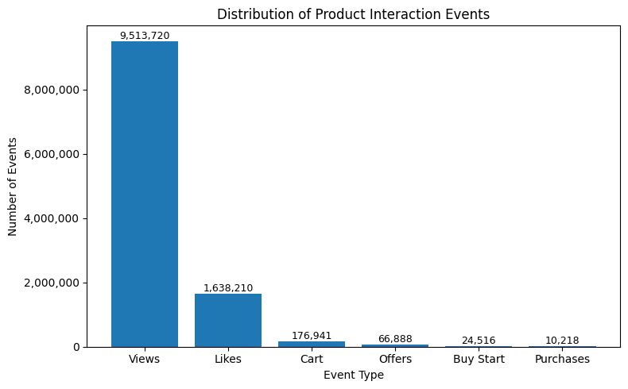

```python
event_pdf = (
    df.groupBy("event_id")
      .count()
      .replace({
          "item_view": "Views",
          "item_like": "Likes",
          "item_add_to_cart_tap": "Cart",
          "offer_make": "Offers",
          "buy_start": "Buy Start",
          "buy_comp": "Purchases"
      }, subset=["event_id"])
      .toPandas()
)

order = ["Views", "Likes", "Cart", "Offers", "Buy Start", "Purchases"]

event_pdf["event_id"] = pd.Categorical(
    event_pdf["event_id"],
    categories=order,
    ordered=True
)
event_pdf = event_pdf.sort_values("event_id")

plt.figure(figsize=(8,5))
bars = plt.bar(event_pdf["event_id"], event_pdf["count"])

plt.title("Distribution of Product Interaction Events")
plt.xlabel("Event Type")
plt.ylabel("Number of Events")

plt.gca().yaxis.set_major_formatter(
    plt.FuncFormatter(lambda x, _: f"{int(x):,}")
)

# Add value labels
for bar in bars:
    h = bar.get_height()
    plt.text(
        bar.get_x() + bar.get_width()/2,
        h,
        f"{int(h):,}",
        ha="center",
        va="bottom",
        fontsize=9
    )

plt.tight_layout()
plt.show()
```

The **top viewed products** span a wide range of **categories** and **brands**, including **Athletic**, **Action Figures**, **Games**, **Paper Collectibles**, and **Home Decor**, indicating diverse customer interests across the marketplace. Well-known brands such as **Nike**, **Funko**, **Nintendo**, **Hasbro**, **Air Jordan**, and **BTS** appear frequently among the most viewed products, although some highly viewed products have **no specified brand**. Additionally, products with high view counts generally receive higher numbers of **likes**, **cart additions**, and **purchases**, demonstrating that multiple engagement metrics effectively capture differences in product popularity and customer interaction, making them valuable features for **product segmentation**.

```python
top_products = (
    df.groupBy("product_id")
      .agg(
          F.first("name").alias("Product"),
          F.first("brand_name").alias("Brand"),
          F.first("c2_name").alias("C2 Category"),

          F.sum(F.when(F.col("event_id") == "item_view", 1).otherwise(0)).alias("Views"),
          F.sum(F.when(F.col("event_id") == "item_like", 1).otherwise(0)).alias("Likes"),
          F.sum(F.when(F.col("event_id") == "item_add_to_cart_tap", 1).otherwise(0)).alias("Cart"),
          F.sum(F.when(F.col("event_id") == "buy_comp", 1).otherwise(0)).alias("Purchases")
      )
      .orderBy(F.desc("Views"))
)

top_products.show(10, truncate=False)
```

```
[Stage 179:>                                                        (0 + 4) / 4]
```

```
+----------+-----------------------------------------------------------------------------+----------+------------------+-----+-----+----+---------+
|product_id|Product                                                                      |Brand     |C2 Category       |Views|Likes|Cart|Purchases|
+----------+-----------------------------------------------------------------------------+----------+------------------+-----+-----+----+---------+
|15987_1224|Nike Lunar Force 1 Duckboot Mens 10 Ale Brown Black Sneakers Boots 805899-202|Nike      |Athletic          |64092|11593|1164|64       |
|7969_2428 |South Park Professor Chaos Funko Pop                                         |Funko     |Bobbleheads       |46929|21778|2655|111      |
|0_561     |Barnyard Farm Animals Christmas Ornament                                     |None      |Action Figures    |43373|6053 |683 |47       |
|15928_1315|Mariokart 8 Deluxe                                                           |Nintendo  |Games             |42931|14060|2058|117      |
|0_904     |Unplugged Book Box Enchantment of Ravens Ceramic Mushroom Lawn Ornament      |None      |Home decor accents|40745|7818 |613 |41       |
|9814_561  |GI Joe custom classified Franklin Talltree Codename Airborne                 |Hasbro    |Action Figures    |34576|7901 |902 |31       |
|436_1224  |Air Jordan 3 Retro                                                           |Air Jordan|Athletic          |32731|6106 |678 |28       |
|3838_585  |BTS MOTS ON:E Concept Suga Holo Photocard                                    |BTS       |Paper Collectibles|31742|13058|1812|69       |
|8886_1176 |Fdny Memorial Shirt (Bronx) E93 L48 B3 Hunts Point (Size XL)                 |Gildan    |T-shirts          |31519|4578 |487 |49       |
|15987_1167|Nike Air Max 270 Shoes                                                       |Nike      |Athletic          |30331|5670 |561 |20       |
+----------+-----------------------------------------------------------------------------+----------+------------------+-----+-----+----+---------+
only showing top 10 rows
```

## Correlation Analysis

Select only the necessary columns to be correlated

```python
pdf = (
    df.select(
        "event_id",
        "c0_name",
        "c1_name",
        "c2_name",
        "brand_name",
        "item_condition_name",
        "price"
    )
    .sample(fraction=0.1, seed=42)
    .toPandas()
)
```

Separate via numeric and categorical columns

```python
numeric_cols = [
    "price"
]

categorical_cols = [
    "c0_name",
    "c1_name",
    "c2_name",
    "brand_name",
    "item_condition_name",
    "event_id"
]
```

Check the first five rows of the selected data

```python
pdf.head()
```

|  | event_id | c0_name | c1_name | c2_name | brand_name | item_condition_name | price |
| --- | --- | --- | --- | --- | --- | --- | --- |
| 0 | item_like | Electronics | Video games & consoles | Games | Nintendo | New | 47.0 |
| 1 | item_view | Women | Women's handbags | Satchel | Coach | New | 249.0 |
| 2 | item_view | Electronics | Other | Other | None | New | 15.0 |
| 3 | item_like | Women | Women's handbags | Tote Bags | Coach | New | 298.0 |
| 4 | item_view | Kids | Boys tops & t-shirts | Boys (4+) | abercrombie kids | Good | 10.0 |

The **Cramér’s V function measures the strength of association between two categorical variables** by applying a **chi-square test** and adjusting for sample size bias, producing a value between **0 and 1**, where values closer to **0 indicate weak or no association** and values closer to **1 indicate a strong relationship** between categories.

```python
def cramers_v(pdf, col1, col2):

    data = pdf[[col1, col2]].dropna()

    confusion_matrix = pd.crosstab(data[col1], data[col2])

    # Need at least 2 categories in each variable
    if confusion_matrix.shape[0] < 2 or confusion_matrix.shape[1] < 2:
        return np.nan

    chi2 = chi2_contingency(confusion_matrix)[0]
    n = confusion_matrix.values.sum()

    phi2 = chi2 / n
    r, k = confusion_matrix.shape

    phi2corr = max(0, phi2 - ((k - 1) * (r - 1)) / (n - 1))
    rcorr = r - ((r - 1) ** 2) / (n - 1)
    kcorr = k - ((k - 1) ** 2) / (n - 1)

    denom = min(kcorr - 1, rcorr - 1)

    if denom <= 0:
        return np.nan

    return np.sqrt(phi2corr / denom)
```

The **Cramér’s V correlation analysis reveals that the product category hierarchy contains strong internal relationships**, where **c0_name and c1_name (0.953)**, **c0_name and c2_name (0.952)**, and **c1_name and c2_name (0.932)** show very strong associations. This is expected because **c1_name and c2_name are more specific subcategories derived from the broader c0_name classification**, meaning products within a higher-level category are highly likely to belong to related lower-level categories.

The analysis also shows that **brand_name has a moderate association with c0_name (0.558)**, indicating that certain brands tend to specialize in specific product categories, while its relationship with more granular categories decreases (**c1_name: 0.365, c2_name: 0.227**), suggesting brands are distributed across multiple subcategories.

Meanwhile, **item_condition_name has weak relationships with product categories (0.120–0.196)**, indicating that product condition is relatively independent of the type of product being sold. Similarly, **event_id has very weak associations with all product attributes (0.035–0.057)**, suggesting that user actions such as views, likes, cart additions, and purchases are not strongly driven by category or brand characteristics alone.

Overall, the results indicate that **category variables are highly redundant due to their hierarchical structure**, while **behavioral signals such as user interactions provide additional independent information that can be valuable for product segmentation and clustering.**

```python
cramers_matrix = pd.DataFrame(
    index=categorical_cols,
    columns=categorical_cols,
    dtype=float
)

for col1 in categorical_cols:
    for col2 in categorical_cols:
        if col1 == col2:
            cramers_matrix.loc[col1, col2] = 1.0
        else:
            cramers_matrix.loc[col1, col2] = cramers_v(pdf, col1, col2)

print(cramers_matrix)
```

```
                      c0_name   c1_name   c2_name  brand_name  \
c0_name              1.000000  0.952637  0.951924    0.558198
c1_name              0.952637  1.000000  0.932307    0.364947
c2_name              0.951924  0.932307  1.000000    0.227430
brand_name           0.558198  0.364947  0.227430    1.000000
item_condition_name  0.120174  0.164001  0.195893    0.198742
event_id             0.035069  0.046992  0.056830    0.051761

                     item_condition_name  event_id
c0_name                         0.120174  0.035069
c1_name                         0.164001  0.046992
c2_name                         0.195893  0.056830
brand_name                      0.198742  0.051761
item_condition_name             1.000000  0.016732
event_id                        0.016732  1.000000
```

The **correlation ratio (η, eta)** function measures the strength of the relationship between a **categorical variable and a numerical variable** by comparing the variation of numerical values between different categories against the total variation in the dataset. The metric ranges from **0 to 1**, where values closer to **0 indicate that category groups have similar numerical distributions (weak or no relationship)**, while values closer to **1 indicate that the numerical variable differs significantly across categories (strong relationship)**.

The function first removes missing values, separates the numerical measurements by category, and calculates the **overall mean** of the numerical variable. It then measures how much of the total variance is explained by differences between category groups using the ratio of **between-group variance to total variance**. A square root transformation is applied to return the final correlation ratio value, which represents the strength of association between the categorical and numerical variables.

This metric is useful for analyzing relationships such as whether **product categories, brands, or item conditions influence numerical behaviors** like price, views, likes, purchases, or user engagement metrics.

```python
def correlation_ratio(pdf, cat_col, num_col):
    data = pdf[[cat_col, num_col]].dropna()

    categories = pd.Categorical(data[cat_col])
    measurements = data[num_col].values

    grand_mean = np.mean(measurements)

    numerator = 0
    denominator = np.sum((measurements - grand_mean) ** 2)

    for category in categories.categories:
        values = measurements[categories == category]

        if len(values) == 0:
            continue

        numerator += len(values) * (np.mean(values) - grand_mean) ** 2

    if denominator == 0:
        return np.nan

    return np.sqrt(numerator / denominator)
```

The **correlation ratio (η) analysis between categorical features and product price** shows that **brand_name has the strongest relationship with price (η = 0.454)**, suggesting that certain brands are associated with different pricing levels and may significantly influence product value.

Among the category variables, **c2_name shows the highest association with price (η = 0.321)**, followed by **c1_name (η = 0.254)** and **c0_name (η = 0.118)**. This indicates that more specific product categories tend to provide better separation of price ranges, as detailed subcategories capture differences between product types more effectively than broad categories.

In contrast, **item_condition_name has almost no relationship with price (η = 0.020)**, suggesting that condition labels such as new, good, fair, or poor do not strongly determine the listed price in this dataset. Similarly, **event_id shows a very weak association with price (η = 0.036)**, indicating that user interaction types are largely independent of product pricing.

Overall, the results suggest that **brand and detailed product categories are more informative predictors of price**, while **item condition and user behavior events contribute limited information for explaining price variation**.

```python
eta_matrix = pd.DataFrame(
    index=categorical_cols,
    columns=numeric_cols,
    dtype=float
)

for cat in categorical_cols:
    for num in numeric_cols:
        eta_matrix.loc[cat, num] = correlation_ratio(
            pdf,
            cat,
            num
        )

print(eta_matrix)
```

```
                        price
c0_name              0.117701
c1_name              0.253735
c2_name              0.320899
brand_name           0.453682
item_condition_name  0.019712
event_id             0.035541
```